# Case Study: Flight Delays

# Introduction and goals

This case study aims to perform quality assessment, regression and clustering on a dataset published by DOT’s Bureau of Transportation Statistics containing information obtained in 2015 about the on-time performance of domestic flights operated by large air carriers.

To address different correlation metrices, two external datasets with passengers per airport and weather data is added.

# Environment preparation

```r
# loading required packages
packages <- c("ggplot2", "GGally", "corrplot", "scales", "gridExtra",
              "lubridate", "grid", "ggpubr", "RColorBrewer", "dplyr",
              "ggforce", "waffle", "reshape2", "cluster", "fpc", "NbClust",
              "data.table", "network", "ggraph", "factoextra")

# invisible to apply the require function without output messages
invisible(lapply(packages, require, character.only = T, quietly = T))
```

# Data input

```r
# setting file path once (easier to change for testing on multiple machines)
csv_path = "data/"
image_path = "images/"

# dataset imports into a data frame
airlines <- fread(paste(csv_path, "airlines.csv", sep=""))
airports <- fread(paste(csv_path, "airports.csv", sep=""))
flights <- fread(paste(csv_path, "flights.csv", sep=""))
passengers <- fread(paste(csv_path, "passengers-per-airport.csv", sep=""))
```

First considerations about input show in the raw dataset:

- 14 airlines;
- 322 airports;
- 5 819 079 flights.

This information needs to be subject of cleansing and quality checks.

# Structure of Data and Quality Assessment

```r
nrow(flights[complete.cases(flights), ])
```

```
## [1] 1063439
```

```r
nrow(airlines[complete.cases(airlines), ])
```

```
## [1] 14
```

```r
nrow(airports[complete.cases(airports), ])
```

```
## [1] 319
```

Only 20% of data is complete on flights: this is likely because in case of no delay there is NA, therefore to obtain a more comprehensive insight it is possible to check whether there are NA in the other columns (the first 23).

```r
nrow(flights[complete.cases(flights[, 1:23]), ])
```

```
## [1] 5714008
```

This gives a better result. Now it is a good idea to zoom on the incomplete values and understand which columns they belong to.

```r
# which columns actually have NA (or infinite)?
na_inf_airlines <- apply(airlines, 2, function(x) any(is.na(x) | is.infinite(x)))

# extraction of column names
# apply returns a named logical vector of which the true columns are extracted
names(na_inf_airlines[na_inf_airlines])  # null (nothing is missing)
```

```
## character(0)
```

```r
na_inf_airports <- apply(airports, 2, function(x) any(is.na(x) | is.infinite(x)))
names(na_inf_airports[na_inf_airports])
```

```
## [1] "LATITUDE"  "LONGITUDE"
```

```r
na_inf_flights <- apply(flights, 2, function(x) any(is.na(x) | is.infinite(x)))
names(na_inf_flights[na_inf_flights])  # delay, departure, arrival
```

```
##  [1] "DEPARTURE_TIME"      "DEPARTURE_DELAY"     "TAXI_OUT"
##  [4] "WHEELS_OFF"          "SCHEDULED_TIME"      "ELAPSED_TIME"
##  [7] "AIR_TIME"            "WHEELS_ON"           "TAXI_IN"
## [10] "ARRIVAL_TIME"        "ARRIVAL_DELAY"       "AIR_SYSTEM_DELAY"
## [13] "SECURITY_DELAY"      "AIRLINE_DELAY"       "LATE_AIRCRAFT_DELAY"
## [16] "WEATHER_DELAY"
```

The preliminary result on a first check on null values gives that the overall presence of complete information is good: airlines are all present, while only 3 airports are missing just latitude or longitude. Since the analysis does not concern spatial analysis of airports and the information can be obtained through external sources, all airports can be used.

Flights are concerned by the biggest amount of missing data: this is either due to inaccuracy, or (rather) to lack of flight delay (or specific kinds of delay).

More information on the weight of NA on flights needs to be therefore acquired. Since departure and arrival time are essential fields for analysis, all flights with NA must be removed.

# Data Preprocessing

```r
flights <- flights[complete.cases(flights$DEPARTURE_TIME)]
flights <- flights[complete.cases(flights$ARRIVAL_TIME)]
# 5 726 566
```

After completing assessment of null and zero values, it is necessary to perform an evaluation of the correctness of information.

Some flights have origin or destination airport not present in the dataset, hence they must be removed as well.

```r
# removing incorrect IATA codes
flights <- flights[flights$ORIGIN_AIRPORT %in% airports$IATA_CODE]
flights <- flights[flights$DESTINATION_AIRPORT %in% airports$IATA_CODE]

nrow(flights)
```

```
## [1] 5242972
```

```r
nrow(flights[flights$AIRLINE %in% airlines$IATA_CODE, ]) # same number (all correct)
```

```
## [1] 5242972
```

## Exploratory analytics

After removing incorrect values, it is possible to begin analysing delays with simple statistics.

```r
# checking how many flights left/arrived with delay
nrow(flights[complete.cases(flights$DEPARTURE_DELAY)])
```

```
## [1] 5242972
```

```r
nrow(flights[complete.cases(flights$ARRIVAL_DELAY)])
```

```
## [1] 5231130
```

```r
# further checking whether the dataset contains zero
nrow(flights[which(flights$DEPARTURE_DELAY == 0), ])
```

```
## [1] 299424
```

```r
nrow(flights[which(flights$ARRIVAL_DELAY == 0)])
```

```
## [1] 115381
```

```r
# checking negative values on departure and arrival delay
nrow(flights[which(flights$DEPARTURE_DELAY < 0), ])
```

```
## [1] 2967194
```

```r
nrow(flights[which(flights$ARRIVAL_DELAY < 0)])
```

```
## [1] 3170103
```

```r
nrow(flights[which(flights$DEPARTURE_DELAY < 0 & flights$ARRIVAL_DELAY < 0), ])
```

```
## [1] 2447206
```

Since research is focussed on flight delays, information about flights arriving on time or early can be removed.

```r
# keeping flights that leave late or arrive late
flights <- flights[which(flights$DEPARTURE_DELAY > 0 | flights$ARRIVAL_DELAY > 0), ]
```

Considerations:

Counting the number of flights with delays per airline gives:

```r
flights[ARRIVAL_DELAY > 0, .N, by = AIRLINE][order(-N)]
```

| AIRLINE | N |
| --- | --- |
| WN | 440052 |
| DL | 234999 |
| AA | 229569 |
| OO | 205771 |
| EV | 197910 |
| UA | 174497 |
| MQ | 98767 |
| B6 | 93849 |
| US | 76285 |
| NK | 52634 |

[output cut: 4 more lines]

Having available information related to months and days gives a good opportunity to perform time series analysis. An instance of that is weather delays, which is briefly shown below to be looked into in the further part of the work.

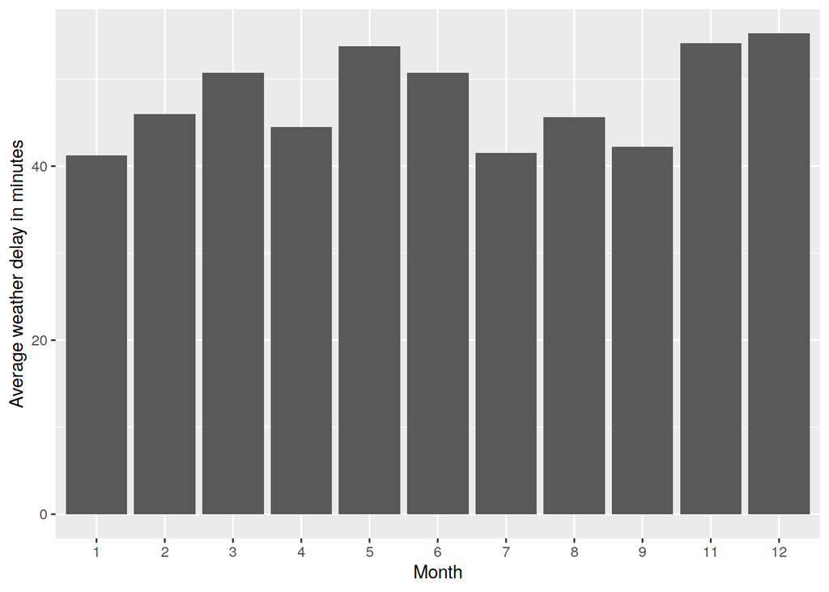

```r
avg_delay_month <- flights[WEATHER_DELAY > 0, mean(WEATHER_DELAY),  by = MONTH]

avg_delay_month$MONTH <- as.factor(avg_delay_month$MONTH)

ggplot(avg_delay_month, aes(x=MONTH, y=V1)) +
  labs(x="Month", y="Average weather delay in minutes") +
  geom_bar(stat="identity")
```

Mean and variance are also potentially interesting indicators to show anomalies and general trends.

```r
# 5 airports with the biggest number of incoming flights
flights[, .N, by = DESTINATION_AIRPORT][order(-N)][1:10]
```

| DESTINATION_AIRPORT | N |
| --- | --- |
| ATL | 143444 |
| ORD | 130339 |
| LAX | 106637 |
| DFW | 102806 |
| DEN | 95808 |
| SFO | 76920 |
| PHX | 71541 |
| IAH | 69177 |
| LAS | 65595 |
| MCO | 54914 |

```r
# mean and standard deviation of number of incoming flights
mean(flights[, .N, by = DESTINATION_AIRPORT]$N)
```

```
## [1] 7785.845
```

```r
sd(flights[, .N, by = DESTINATION_AIRPORT]$N)
```

```
## [1] 18776.46
```

```r
# same thing with outcoming flights
flights[, .N, by = ORIGIN_AIRPORT][order(-N)][1:10]
```

| ORIGIN_AIRPORT | N |
| --- | --- |
| ATL | 158268 |
| ORD | 145917 |
| DFW | 117684 |
| DEN | 106466 |
| LAX | 103073 |
| IAH | 77345 |
| PHX | 75542 |
| SFO | 73230 |
| LAS | 68625 |
| SEA | 56210 |

```r
mean(flights[, .N, by = ORIGIN_AIRPORT]$N)
```

```
## [1] 7785.845
```

```r
sd(flights[, .N, by = ORIGIN_AIRPORT]$N)
```

```
## [1] 20020.83
```

In presence of a null value, there are two feasible choices: replacing them with 0 (no delay) or ignoring them while computing statistics.

```r
# mean arrival and departure delay (without NA)
mean(flights$DEPARTURE_DELAY, na.rm = TRUE)
```

```
## [1] 25.26682
```

```r
mean(flights$ARRIVAL_DELAY, na.rm = TRUE)
```

```
## [1] 24.27084
```

```r
# mean arrival and departure delay (assuming NA = 0)
flights0 <- copy(flights)  # copy to avoid reference
flights0[is.na(flights0)] <- 0
mean(flights0$DEPARTURE_DELAY)
```

```
## [1] 25.26682
```

```r
mean(flights0$ARRIVAL_DELAY)
```

```
## [1] 24.21317
```

The two results for mean and standard deviation are similar: to understand what dataset to use, it can be seen how many NA values get replaced in practice.

```r
flights[(is.na(ARRIVAL_DELAY)), .N, ]
```

```
## [1] 5957
```

```r
flights[(is.na(DEPARTURE_DELAY)), .N, ]
```

```
## [1] 0
```

```r
flights[(DEPARTURE_DELAY == 0), .N, ]
```

```
## [1] 77883
```

```r
flights[(ARRIVAL_DELAY == 0), .N, ]
```

```
## [1] 43716
```

The number of missing values is a very small percentage compared to the total amount of available data. Those, however, need to be taken into account and filtered while performing analysis and statistics on delays.

```r
# mean arrival and departure delay for each airport
mean(flights$DEPARTURE_DELAY, na.rm = TRUE)
```

```
## [1] 25.26682
```

```r
mean(flights$ARRIVAL_DELAY, na.rm = TRUE)
```

```
## [1] 24.27084
```

```r
# mean arrival and departure delay for each airline
flights[, mean(DEPARTURE_DELAY), by = AIRLINE][order(-V1)]
```

| AIRLINE | V1 |
| --- | --- |
| NK | 32.948050 |
| F9 | 32.512666 |
| B6 | 29.833052 |
| MQ | 29.702147 |
| UA | 29.263996 |
| EV | 27.357715 |
| OO | 25.579702 |
| AA | 25.439161 |
| WN | 23.724913 |
| DL | 23.245516 |

[output cut: 4 more lines]

```r
flights[, mean(ARRIVAL_DELAY), by = AIRLINE][order(-V1)]
```

| AIRLINE | V1 |
| --- | --- |
| US | NA |
| DL | NA |
| NK | NA |
| AA | NA |
| HA | NA |
| UA | NA |
| B6 | NA |
| OO | NA |
| EV | NA |
| F9 | NA |

[output cut: 4 more lines]

```r
# airlines with their number of delayed arrivals
flights[(DEPARTURE_DELAY > 0), .N, by = AIRLINE][order(-N)]
```

| AIRLINE | N |
| --- | --- |
| WN | 526522 |
| DL | 263322 |
| UA | 238964 |
| AA | 223528 |
| OO | 159662 |
| EV | 158465 |
| B6 | 93615 |
| MQ | 88679 |
| US | 62418 |
| NK | 48402 |

[output cut: 4 more lines]

```r
flights[(ARRIVAL_DELAY > 0), .N, by = AIRLINE][order(-N)]
```

| AIRLINE | N |
| --- | --- |
| WN | 440052 |
| DL | 234999 |
| AA | 229569 |
| OO | 205771 |
| EV | 197910 |
| UA | 174497 |
| MQ | 98767 |
| B6 | 93849 |
| US | 76285 |
| NK | 52634 |

[output cut: 4 more lines]

After performing the first general analysis, it is possible to begin with more detailed results.